# mp4.5

```python
# NOTE: Loading data from Google Drive is VERY SLOW. Therefore, we download the data to a local storage
# specified by VOC_PATH.
# This means the data would have be re-downloaded everytime.
# Change this path if you are running this script locally
VOC_PATH="./VOC_DATA"
```

```python
# %%bash
# VOC_PATH="./VOC_DATA"
# chmod u+x ./download_data.sh
# sed -i 's/\r//g' ./download_data.sh
# cat ./download_data.sh
# bash ./download_data.sh $VOC_PATH
```

```python
import os
import random

import cv2
import numpy as np

import torch
from torch.utils.data import DataLoader

from src.resnet_yolo import resnet50
import yolo_loss
from src.dataset import VocDetectorDataset
from src.eval_voc import evaluate
from src.predict import predict_image
from src.config import VOC_CLASSES, COLORS
from kaggle_submission import output_submission_csv

import matplotlib.pyplot as plt # type: ignore
import collections

%matplotlib inline
%load_ext autoreload
%autoreload 2
```

```
The autoreload extension is already loaded. To reload it, use:
  %reload_ext autoreload
```

## Initialization

```python
device = torch.device("cuda:0" if torch.cuda.is_available() else "cpu")
```

```python
# YOLO network hyperparameters
B = 2  # number of bounding box predictions per cell
S = 14  # width/height of network output grid (larger than 7x7 from paper since we use a different network)
```

## **Start from here if you modified yolo_loss.py and wish to retrain**

```python
# We recommend tuning only the batch size; the remaining hyperparameters should work well
# with the default values. However, you are free to experiment with them.

learning_rate = 0.001
num_epochs = 50
batch_size = 12

# Yolo loss component coefficients (as given in Yolo v1 paper)
lambda_coord = 5
lambda_noobj = 0.5
```

## Reading Pascal Data

Since Pascal is a small dataset (5000 in train+val) we have combined the train and val splits to train our detector. This is not typically a good practice, but we will make an exception in this case to be able to get reasonable detection results with a comparatively small object detection dataset.

The train dataset loader also using a variety of data augmentation techniques including random shift, scaling, crop, and flips. Data augmentation is slightly more complicated for detection datasets since the bounding box annotations must be kept consistent throughout the transformations.

Since the output of the detector network we train is an SxSx(B*5+C), we use an encoder to convert the original bounding box coordinates into relative grid bounding box coordinates corresponding to the expected output. We also use a decoder which allows us to convert the opposite direction into image coordinate bounding boxes.

```python
file_root_train = os.path.join(VOC_PATH, 'VOCdevkit_2007/VOC2007/JPEGImages/')
annotation_file_train = 'data/voc2007.txt'

train_dataset = VocDetectorDataset(root_img_dir=file_root_train,dataset_file=annotation_file_train,train=True, S=S)
train_loader = DataLoader(train_dataset,batch_size=batch_size,shuffle=True,num_workers=12)
print('Loaded %d train images' % len(train_dataset))
```

```
Initializing dataset
Loaded 5011 train images
```

```python
file_root_test = os.path.join(VOC_PATH, 'VOCdevkit_2007/VOC2007test/JPEGImages/')
annotation_file_test = 'data/voc2007test.txt'

test_dataset = VocDetectorDataset(root_img_dir=file_root_test,dataset_file=annotation_file_test,train=False, S=S)
test_loader = DataLoader(test_dataset,batch_size=batch_size,shuffle=False,num_workers=12)
print('Loaded %d test images' % len(test_dataset))
```

```
Initializing dataset
Loaded 4950 test images
```

```python
data = train_dataset[0]
```

## Initializing the network

To implement Yolo we will rely on a pretrained classifier as the backbone for our detection network. PyTorch offers a variety of models which are pretrained on ImageNet in the [`torchvision.models`](https://pytorch.org/docs/stable/torchvision/models.html) package. In particular, we will use the ResNet50 architecture as a base for our detector. This is different from the base architecture in the Yolo paper and also results in a different output grid size (14x14 instead of 7x7).

Models are typically pretrained on ImageNet since the dataset is very large (> 1 million images) and widely used. The pretrained model provides a very useful weight initialization for our detector, so that the network is able to learn quickly and effectively.

```python
# load_network_path = None
pretrained = True

# use to load a previously trained network
if load_network_path is not None:
    print('Loading saved network from {}'.format(load_network_path))
    net = resnet50().to(device)
    net.load_state_dict(torch.load(load_network_path))
else:
    print('Load pre-trained model')
    net = resnet50(pretrained=pretrained).to(device)
```

```
Loading saved network from ./checkpoints/detector.pth
```

## Set up training tools

```python
from importlib import reload
reload(yolo_loss) # update the import if the implementation has changed

criterion = yolo_loss.YoloLoss(S, B, lambda_coord, lambda_noobj)
# optimizer = torch.optim.SGD(net.parameters(), lr=learning_rate, momentum=0.9, weight_decay=5e-4)
optimizer = torch.optim.Adam(net.parameters(), lr=learning_rate, weight_decay=5e-4)
```

## Train detector

```python
import time
best_test_loss = np.inf
learning_rate = learning_rate
start_time = time.time()
os.makedirs('./checkpoints', exist_ok=True)
for epoch in range(num_epochs):
    net.train()

    # Update learning rate late in training
    if epoch == 30 or epoch == 40:
        learning_rate /= 10.0

    for param_group in optimizer.param_groups:
        param_group['lr'] = learning_rate

    print('\n\nStarting epoch %d / %d' % (epoch + 1, num_epochs))
    print('Learning Rate for this epoch: {}'.format(learning_rate))

    total_loss = collections.defaultdict(int)

    for i, data in enumerate(train_loader):
        data = (item.to(device) for item in data)
        images, target_boxes, target_cls, has_object_map = data
        pred = net(images)
        loss_dict = criterion(pred, target_boxes, target_cls, has_object_map)
        for key in loss_dict:
            total_loss[key] += loss_dict[key].item()

        optimizer.zero_grad()
        loss_dict['total_loss'].backward()
        optimizer.step()

        if (i+1) % 50 == 0:
            outstring = 'Epoch [%d/%d], Iter [%d/%d], Loss: ' % ((epoch+1, num_epochs, i+1, len(train_loader)))
            outstring += ', '.join( "%s=%.3f" % (key[:-5], val / (i+1)) for key, val in total_loss.items() )
            print(outstring)

    # evaluate the network on the test data
    if (epoch + 1) % 5 == 0:
        test_aps = evaluate(net, test_dataset_file=annotation_file_test, img_root=file_root_test)
        print(epoch, test_aps)
    with torch.no_grad():
        test_loss = 0.0
        net.eval()
        for i, data in enumerate(test_loader):
            data = (item.to(device) for item in data)
            images, target_boxes, target_cls, has_object_map = data

            pred = net(images)
            loss_dict = criterion(pred, target_boxes, target_cls, has_object_map)
            test_loss += loss_dict['total_loss'].item()
        test_loss /= len(test_loader)

    if best_test_loss > test_loss:
        best_test_loss = test_loss
        print('Updating best test loss: %.5f' % best_test_loss)
        torch.save(net.state_dict(),'checkpoints/best_detector.pth')

    if (epoch+1) in [5, 10, 20, 30, 40]:
        torch.save(net.state_dict(),'checkpoints/detector_epoch_%d.pth' % (epoch+1))

    print("Runtime: %.2f, Epoch took: %.2f min" % (time.time() / 60, (time.time() - start_time) / 60))
    torch.save(net.state_dict(),'checkpoints/detector.pth')
```

```
Starting epoch 1 / 50
Learning Rate for this epoch: 1e-05
Epoch [1/50], Iter [50/418], Loss: total=2.008, reg=0.967, containing_obj=0.626, no_obj=0.195, cls=0.220
Epoch [1/50], Iter [100/418], Loss: total=1.988, reg=0.974, containing_obj=0.612, no_obj=0.192, cls=0.210
Epoch [1/50], Iter [150/418], Loss: total=1.965, reg=0.952, containing_obj=0.608, no_obj=0.195, cls=0.210
Epoch [1/50], Iter [200/418], Loss: total=1.936, reg=0.936, containing_obj=0.604, no_obj=0.193, cls=0.202
Epoch [1/50], Iter [250/418], Loss: total=1.955, reg=0.952, containing_obj=0.606, no_obj=0.192, cls=0.205
Epoch [1/50], Iter [300/418], Loss: total=1.955, reg=0.951, containing_obj=0.606, no_obj=0.192, cls=0.205
Epoch [1/50], Iter [350/418], Loss: total=1.984, reg=0.967, containing_obj=0.614, no_obj=0.192, cls=0.211
Epoch [1/50], Iter [400/418], Loss: total=1.968, reg=0.961, containing_obj=0.609, no_obj=0.193, cls=0.205
Updating best test loss: 2.55737
Runtime: 29086493.50, Epoch took: 6.07 min


Starting epoch 2 / 50
Learning Rate for this epoch: 1e-05
Epoch [2/50], Iter [50/418], Loss: total=1.958, reg=0.949, containing_obj=0.623, no_obj=0.184, cls=0.202
Epoch [2/50], Iter [100/418], Loss: total=1.941, reg=0.949, containing_obj=0.622, no_obj=0.183, cls=0.187
Epoch [2/50], Iter [150/418], Loss: total=1.894, reg=0.915, containing_obj=0.607, no_obj=0.188, cls=0.185
Epoch [2/50], Iter [200/418], Loss: total=1.929, reg=0.936, containing_obj=0.611, no_obj=0.186, cls=0.196
Epoch [2/50], Iter [250/418], Loss: total=1.925, reg=0.926, containing_obj=0.612, no_obj=0.188, cls=0.199
Epoch [2/50], Iter [300/418], Loss: total=1.914, reg=0.922, containing_obj=0.609, no_obj=0.187, cls=0.195
Epoch [2/50], Iter [350/418], Loss: total=1.913, reg=0.922, containing_obj=0.608, no_obj=0.188, cls=0.194
Epoch [2/50], Iter [400/418], Loss: total=1.925, reg=0.930, containing_obj=0.612, no_obj=0.188, cls=0.194
Updating best test loss: 2.54898
Runtime: 29086499.63, Epoch took: 12.20 min


Starting epoch 3 / 50
Learning Rate for this epoch: 1e-05
Epoch [3/50], Iter [50/418], Loss: total=2.028, reg=1.007, containing_obj=0.632, no_obj=0.176, cls=0.212
Epoch [3/50], Iter [100/418], Loss: total=1.980, reg=0.979, containing_obj=0.626, no_obj=0.182, cls=0.193
Epoch [3/50], Iter [150/418], Loss: total=1.987, reg=0.977, containing_obj=0.623, no_obj=0.186, cls=0.202
Epoch [3/50], Iter [200/418], Loss: total=1.954, reg=0.964, containing_obj=0.606, no_obj=0.188, cls=0.195
Epoch [3/50], Iter [250/418], Loss: total=1.940, reg=0.949, containing_obj=0.610, no_obj=0.190, cls=0.192
Epoch [3/50], Iter [300/418], Loss: total=1.932, reg=0.943, containing_obj=0.609, no_obj=0.190, cls=0.190
Epoch [3/50], Iter [350/418], Loss: total=1.931, reg=0.942, containing_obj=0.606, no_obj=0.191, cls=0.191
Epoch [3/50], Iter [400/418], Loss: total=1.922, reg=0.938, containing_obj=0.606, no_obj=0.190, cls=0.187
Updating best test loss: 2.54126
Runtime: 29086506.18, Epoch took: 18.75 min
```

[output cut: 11 more lines]

```
Epoch [4/50], Iter [400/418], Loss: total=1.925, reg=0.933, containing_obj=0.606, no_obj=0.192, cls=0.194
Runtime: 29086512.60, Epoch took: 25.17 min


Starting epoch 5 / 50
Learning Rate for this epoch: 1e-05
Epoch [5/50], Iter [50/418], Loss: total=1.905, reg=0.908, containing_obj=0.614, no_obj=0.184, cls=0.199
Epoch [5/50], Iter [100/418], Loss: total=1.839, reg=0.886, containing_obj=0.591, no_obj=0.187, cls=0.175
Epoch [5/50], Iter [150/418], Loss: total=1.851, reg=0.897, containing_obj=0.584, no_obj=0.191, cls=0.180
Epoch [5/50], Iter [200/418], Loss: total=1.895, reg=0.917, containing_obj=0.605, no_obj=0.190, cls=0.182
Epoch [5/50], Iter [250/418], Loss: total=1.901, reg=0.914, containing_obj=0.609, no_obj=0.189, cls=0.188
Epoch [5/50], Iter [300/418], Loss: total=1.896, reg=0.911, containing_obj=0.607, no_obj=0.190, cls=0.188
Epoch [5/50], Iter [350/418], Loss: total=1.897, reg=0.906, containing_obj=0.609, no_obj=0.191, cls=0.192
Epoch [5/50], Iter [400/418], Loss: total=1.900, reg=0.910, containing_obj=0.608, no_obj=0.190, cls=0.192
---Evaluate model on test samples---
```

```
---class aeroplane ap 0.5043015282278073---
---class bicycle ap 0.6773606137621415---
---class bird ap 0.44120655042767154---
---class boat ap 0.3099732563984594---
---class bottle ap 0.14375537777761727---
---class bus ap 0.6226174894737079---
---class car ap 0.6408518217644554---
---class cat ap 0.7202477122819776---
---class chair ap 0.2830660821498139---
---class cow ap 0.5343924785756844---
---class diningtable ap 0.39049601310690446---
---class dog ap 0.7003474780529089---
---class horse ap 0.709946997774902---
---class motorbike ap 0.5869946522882454---
---class person ap 0.500431298258442---
---class pottedplant ap 0.17273352365610106---
---class sheep ap 0.451075143224862---
---class sofa ap 0.4511487227192126---
---class train ap 0.636534752306345---
---class tvmonitor ap 0.47180636270716836---
---map 0.4974643927467214---
4 [np.float64(0.5043015282278073), np.float64(0.6773606137621415), np.float64(0.44120655042767154), np.float64(0.3099732563984594), np.float64(0.14375537777761727), np.float64(0.6226174894737079), np.float64(0.6408518217644554), np.float64(0.7202477122819776), np.float64(0.2830660821498139), np.floa…
Runtime: 29086520.93, Epoch took: 33.50 min


Starting epoch 6 / 50
Learning Rate for this epoch: 1e-05
Epoch [6/50], Iter [50/418], Loss: total=1.855, reg=0.897, containing_obj=0.600, no_obj=0.187, cls=0.172
Epoch [6/50], Iter [100/418], Loss: total=1.853, reg=0.893, containing_obj=0.593, no_obj=0.190, cls=0.178
Epoch [6/50], Iter [150/418], Loss: total=1.881, reg=0.918, containing_obj=0.593, no_obj=0.188, cls=0.182
Epoch [6/50], Iter [200/418], Loss: total=1.882, reg=0.913, containing_obj=0.590, no_obj=0.191, cls=0.186
Epoch [6/50], Iter [250/418], Loss: total=1.914, reg=0.928, containing_obj=0.604, no_obj=0.190, cls=0.192
Epoch [6/50], Iter [300/418], Loss: total=1.889, reg=0.917, containing_obj=0.596, no_obj=0.191, cls=0.186
Epoch [6/50], Iter [350/418], Loss: total=1.870, reg=0.902, containing_obj=0.593, no_obj=0.191, cls=0.185
Epoch [6/50], Iter [400/418], Loss: total=1.888, reg=0.910, containing_obj=0.601, no_obj=0.191, cls=0.186
Runtime: 29086527.16, Epoch took: 39.73 min


Starting epoch 7 / 50
Learning Rate for this epoch: 1e-05
```

[output cut: 34 more lines]

```
Epoch [9/50], Iter [400/418], Loss: total=1.840, reg=0.879, containing_obj=0.590, no_obj=0.191, cls=0.180
Runtime: 29086545.59, Epoch took: 58.16 min


Starting epoch 10 / 50
Learning Rate for this epoch: 1e-05
Epoch [10/50], Iter [50/418], Loss: total=1.704, reg=0.790, containing_obj=0.549, no_obj=0.199, cls=0.165
Epoch [10/50], Iter [100/418], Loss: total=1.764, reg=0.830, containing_obj=0.567, no_obj=0.190, cls=0.176
Epoch [10/50], Iter [150/418], Loss: total=1.825, reg=0.873, containing_obj=0.585, no_obj=0.187, cls=0.179
Epoch [10/50], Iter [200/418], Loss: total=1.815, reg=0.874, containing_obj=0.577, no_obj=0.190, cls=0.174
Epoch [10/50], Iter [250/418], Loss: total=1.834, reg=0.880, containing_obj=0.588, no_obj=0.190, cls=0.176
Epoch [10/50], Iter [300/418], Loss: total=1.844, reg=0.883, containing_obj=0.594, no_obj=0.189, cls=0.177
Epoch [10/50], Iter [350/418], Loss: total=1.840, reg=0.883, containing_obj=0.595, no_obj=0.190, cls=0.173
Epoch [10/50], Iter [400/418], Loss: total=1.844, reg=0.882, containing_obj=0.594, no_obj=0.190, cls=0.177
---Evaluate model on test samples---
```

```
---class aeroplane ap 0.5110567491542779---
---class bicycle ap 0.674480392409495---
---class bird ap 0.4780949143035722---
---class boat ap 0.32924003045234157---
---class bottle ap 0.1794282706619576---
---class bus ap 0.6534453182960254---
---class car ap 0.6756108689264962---
---class cat ap 0.7452438391597491---
---class chair ap 0.31853263580898583---
---class cow ap 0.5412112448838335---
---class diningtable ap 0.4021632294061467---
---class dog ap 0.6661154121963877---
---class horse ap 0.6877876659752677---
---class motorbike ap 0.6025386560725838---
---class person ap 0.5372200630967134---
---class pottedplant ap 0.20253881333901438---
---class sheep ap 0.5220922571866156---
---class sofa ap 0.45537918241163866---
---class train ap 0.6397049940836173---
---class tvmonitor ap 0.510919574874078---
---map 0.5166402056349398---
9 [np.float64(0.5110567491542779), np.float64(0.674480392409495), np.float64(0.4780949143035722), np.float64(0.32924003045234157), np.float64(0.1794282706619576), np.float64(0.6534453182960254), np.float64(0.6756108689264962), np.float64(0.7452438391597491), np.float64(0.31853263580898583), np.float…
Runtime: 29086553.53, Epoch took: 66.10 min


Starting epoch 11 / 50
Learning Rate for this epoch: 1e-05
Epoch [11/50], Iter [50/418], Loss: total=1.753, reg=0.838, containing_obj=0.554, no_obj=0.196, cls=0.164
Epoch [11/50], Iter [100/418], Loss: total=1.830, reg=0.883, containing_obj=0.589, no_obj=0.194, cls=0.165
Epoch [11/50], Iter [150/418], Loss: total=1.847, reg=0.882, containing_obj=0.597, no_obj=0.191, cls=0.176
Epoch [11/50], Iter [200/418], Loss: total=1.836, reg=0.882, containing_obj=0.588, no_obj=0.193, cls=0.172
Epoch [11/50], Iter [250/418], Loss: total=1.864, reg=0.898, containing_obj=0.597, no_obj=0.191, cls=0.178
Epoch [11/50], Iter [300/418], Loss: total=1.859, reg=0.896, containing_obj=0.592, no_obj=0.193, cls=0.178
Epoch [11/50], Iter [350/418], Loss: total=1.850, reg=0.890, containing_obj=0.590, no_obj=0.192, cls=0.178
Epoch [11/50], Iter [400/418], Loss: total=1.856, reg=0.898, containing_obj=0.590, no_obj=0.191, cls=0.176
Runtime: 29086559.46, Epoch took: 72.03 min


Starting epoch 12 / 50
Learning Rate for this epoch: 1e-05
```

[output cut: 33 more lines]

```
Epoch [14/50], Iter [400/418], Loss: total=1.775, reg=0.845, containing_obj=0.576, no_obj=0.190, cls=0.163
Runtime: 29086576.90, Epoch took: 89.47 min


Starting epoch 15 / 50
Learning Rate for this epoch: 1e-05
Epoch [15/50], Iter [50/418], Loss: total=1.800, reg=0.847, containing_obj=0.579, no_obj=0.194, cls=0.180
Epoch [15/50], Iter [100/418], Loss: total=1.764, reg=0.834, containing_obj=0.568, no_obj=0.192, cls=0.170
Epoch [15/50], Iter [150/418], Loss: total=1.776, reg=0.848, containing_obj=0.570, no_obj=0.190, cls=0.168
Epoch [15/50], Iter [200/418], Loss: total=1.782, reg=0.855, containing_obj=0.575, no_obj=0.189, cls=0.164
Epoch [15/50], Iter [250/418], Loss: total=1.770, reg=0.851, containing_obj=0.569, no_obj=0.189, cls=0.161
Epoch [15/50], Iter [300/418], Loss: total=1.769, reg=0.849, containing_obj=0.571, no_obj=0.189, cls=0.160
Epoch [15/50], Iter [350/418], Loss: total=1.772, reg=0.850, containing_obj=0.573, no_obj=0.189, cls=0.159
Epoch [15/50], Iter [400/418], Loss: total=1.789, reg=0.857, containing_obj=0.580, no_obj=0.189, cls=0.163
---Evaluate model on test samples---
```

```
---class aeroplane ap 0.49396557166333854---
---class bicycle ap 0.6458986166491953---
---class bird ap 0.45891772808236975---
---class boat ap 0.3187974195132091---
---class bottle ap 0.1749032673061928---
---class bus ap 0.663701759769374---
---class car ap 0.6623439930786745---
---class cat ap 0.7351179363401772---
---class chair ap 0.3203349685830117---
---class cow ap 0.5279671451987518---
---class diningtable ap 0.4103546027354925---
---class dog ap 0.6891053364522048---
---class horse ap 0.7045628782751363---
---class motorbike ap 0.5825256265927303---
---class person ap 0.5324891141920531---
---class pottedplant ap 0.19031504335642507---
---class sheep ap 0.5281758636956373---
---class sofa ap 0.4823955882524575---
---class train ap 0.6465161174112015---
---class tvmonitor ap 0.5254333676539986---
---map 0.5146910972400816---
14 [np.float64(0.49396557166333854), np.float64(0.6458986166491953), np.float64(0.45891772808236975), np.float64(0.3187974195132091), np.float64(0.1749032673061928), np.float64(0.663701759769374), np.float64(0.6623439930786745), np.float64(0.7351179363401772), np.float64(0.3203349685830117), np.floa…
Runtime: 29086584.77, Epoch took: 97.34 min


Starting epoch 16 / 50
Learning Rate for this epoch: 1e-05
Epoch [16/50], Iter [50/418], Loss: total=1.871, reg=0.927, containing_obj=0.597, no_obj=0.191, cls=0.156
Epoch [16/50], Iter [100/418], Loss: total=1.818, reg=0.884, containing_obj=0.584, no_obj=0.192, cls=0.158
Epoch [16/50], Iter [150/418], Loss: total=1.810, reg=0.874, containing_obj=0.580, no_obj=0.192, cls=0.164
Epoch [16/50], Iter [200/418], Loss: total=1.821, reg=0.877, containing_obj=0.589, no_obj=0.191, cls=0.164
Epoch [16/50], Iter [250/418], Loss: total=1.798, reg=0.861, containing_obj=0.579, no_obj=0.192, cls=0.166
Epoch [16/50], Iter [300/418], Loss: total=1.788, reg=0.853, containing_obj=0.576, no_obj=0.192, cls=0.167
Epoch [16/50], Iter [350/418], Loss: total=1.790, reg=0.859, containing_obj=0.572, no_obj=0.190, cls=0.169
Epoch [16/50], Iter [400/418], Loss: total=1.786, reg=0.859, containing_obj=0.570, no_obj=0.190, cls=0.168
Runtime: 29086590.63, Epoch took: 103.21 min


Starting epoch 17 / 50
Learning Rate for this epoch: 1e-05
```

[output cut: 34 more lines]

```
Epoch [19/50], Iter [400/418], Loss: total=1.773, reg=0.847, containing_obj=0.567, no_obj=0.193, cls=0.166
Runtime: 29086607.98, Epoch took: 120.55 min


Starting epoch 20 / 50
Learning Rate for this epoch: 1e-05
Epoch [20/50], Iter [50/418], Loss: total=1.694, reg=0.829, containing_obj=0.522, no_obj=0.185, cls=0.159
Epoch [20/50], Iter [100/418], Loss: total=1.723, reg=0.833, containing_obj=0.546, no_obj=0.180, cls=0.164
Epoch [20/50], Iter [150/418], Loss: total=1.726, reg=0.832, containing_obj=0.546, no_obj=0.183, cls=0.166
Epoch [20/50], Iter [200/418], Loss: total=1.715, reg=0.820, containing_obj=0.547, no_obj=0.186, cls=0.162
Epoch [20/50], Iter [250/418], Loss: total=1.742, reg=0.834, containing_obj=0.559, no_obj=0.187, cls=0.161
Epoch [20/50], Iter [300/418], Loss: total=1.732, reg=0.829, containing_obj=0.558, no_obj=0.188, cls=0.157
Epoch [20/50], Iter [350/418], Loss: total=1.730, reg=0.825, containing_obj=0.560, no_obj=0.188, cls=0.157
Epoch [20/50], Iter [400/418], Loss: total=1.735, reg=0.829, containing_obj=0.561, no_obj=0.189, cls=0.156
---Evaluate model on test samples---
```

```
---class aeroplane ap 0.5006551915521552---
---class bicycle ap 0.6521257371183233---
---class bird ap 0.5038827315301657---
---class boat ap 0.31808675488603955---
---class bottle ap 0.19228929347757973---
---class bus ap 0.6397279278990682---
---class car ap 0.6703458933671793---
---class cat ap 0.7204356908763405---
---class chair ap 0.31472819355040776---
---class cow ap 0.5327150778903096---
---class diningtable ap 0.4099861993724629---
---class dog ap 0.6795501071438432---
---class horse ap 0.6901173009282385---
---class motorbike ap 0.5725876614730714---
---class person ap 0.5278891205282898---
---class pottedplant ap 0.20185695873046092---
---class sheep ap 0.5622749196434329---
---class sofa ap 0.466511382098481---
---class train ap 0.6638215654472981---
---class tvmonitor ap 0.5078679577865801---
---map 0.5163727832649865---
19 [np.float64(0.5006551915521552), np.float64(0.6521257371183233), np.float64(0.5038827315301657), np.float64(0.31808675488603955), np.float64(0.19228929347757973), np.float64(0.6397279278990682), np.float64(0.6703458933671793), np.float64(0.7204356908763405), np.float64(0.31472819355040776), np.fl…
Runtime: 29086615.70, Epoch took: 128.27 min


Starting epoch 21 / 50
Learning Rate for this epoch: 1e-05
Epoch [21/50], Iter [50/418], Loss: total=1.677, reg=0.771, containing_obj=0.560, no_obj=0.198, cls=0.148
Epoch [21/50], Iter [100/418], Loss: total=1.676, reg=0.782, containing_obj=0.549, no_obj=0.196, cls=0.149
Epoch [21/50], Iter [150/418], Loss: total=1.681, reg=0.785, containing_obj=0.549, no_obj=0.192, cls=0.155
Epoch [21/50], Iter [200/418], Loss: total=1.689, reg=0.793, containing_obj=0.549, no_obj=0.193, cls=0.153
Epoch [21/50], Iter [250/418], Loss: total=1.709, reg=0.803, containing_obj=0.560, no_obj=0.193, cls=0.154
Epoch [21/50], Iter [300/418], Loss: total=1.727, reg=0.812, containing_obj=0.563, no_obj=0.192, cls=0.160
Epoch [21/50], Iter [350/418], Loss: total=1.746, reg=0.828, containing_obj=0.564, no_obj=0.192, cls=0.161
Epoch [21/50], Iter [400/418], Loss: total=1.740, reg=0.825, containing_obj=0.565, no_obj=0.192, cls=0.159
Runtime: 29086621.52, Epoch took: 134.09 min


Starting epoch 22 / 50
Learning Rate for this epoch: 1e-05
```

[output cut: 35 more lines]

```
Updating best test loss: 2.50542
Runtime: 29086639.14, Epoch took: 151.71 min


Starting epoch 25 / 50
Learning Rate for this epoch: 1e-05
Epoch [25/50], Iter [50/418], Loss: total=1.782, reg=0.892, containing_obj=0.564, no_obj=0.183, cls=0.143
Epoch [25/50], Iter [100/418], Loss: total=1.724, reg=0.827, containing_obj=0.568, no_obj=0.184, cls=0.146
Epoch [25/50], Iter [150/418], Loss: total=1.709, reg=0.820, containing_obj=0.555, no_obj=0.185, cls=0.149
Epoch [25/50], Iter [200/418], Loss: total=1.688, reg=0.809, containing_obj=0.546, no_obj=0.188, cls=0.146
Epoch [25/50], Iter [250/418], Loss: total=1.713, reg=0.818, containing_obj=0.559, no_obj=0.188, cls=0.149
Epoch [25/50], Iter [300/418], Loss: total=1.712, reg=0.813, containing_obj=0.559, no_obj=0.190, cls=0.150
Epoch [25/50], Iter [350/418], Loss: total=1.718, reg=0.815, containing_obj=0.561, no_obj=0.192, cls=0.150
Epoch [25/50], Iter [400/418], Loss: total=1.727, reg=0.819, containing_obj=0.563, no_obj=0.193, cls=0.152
---Evaluate model on test samples---
```

```
---class aeroplane ap 0.5270797579713655---
---class bicycle ap 0.6525989304728592---
---class bird ap 0.46854490042330715---
---class boat ap 0.3350804299832547---
---class bottle ap 0.1996203676714536---
---class bus ap 0.648547105278832---
---class car ap 0.6609858967723963---
---class cat ap 0.7282658426659516---
---class chair ap 0.3005383539063467---
---class cow ap 0.5592809638078665---
---class diningtable ap 0.4254911057966337---
---class dog ap 0.6819222395084013---
---class horse ap 0.7066830036731877---
---class motorbike ap 0.5990673163755007---
---class person ap 0.5328548954326778---
---class pottedplant ap 0.185237190689104---
---class sheep ap 0.5035911685303371---
---class sofa ap 0.4739781992293198---
---class train ap 0.6671092233215605---
---class tvmonitor ap 0.5298899073255561---
---map 0.5193183399417955---
24 [np.float64(0.5270797579713655), np.float64(0.6525989304728592), np.float64(0.46854490042330715), np.float64(0.3350804299832547), np.float64(0.1996203676714536), np.float64(0.648547105278832), np.float64(0.6609858967723963), np.float64(0.7282658426659516), np.float64(0.3005383539063467), np.float…
Runtime: 29086647.75, Epoch took: 160.33 min


Starting epoch 26 / 50
Learning Rate for this epoch: 1e-05
Epoch [26/50], Iter [50/418], Loss: total=1.611, reg=0.762, containing_obj=0.525, no_obj=0.190, cls=0.134
Epoch [26/50], Iter [100/418], Loss: total=1.668, reg=0.773, containing_obj=0.554, no_obj=0.191, cls=0.151
Epoch [26/50], Iter [150/418], Loss: total=1.673, reg=0.787, containing_obj=0.556, no_obj=0.190, cls=0.141
Epoch [26/50], Iter [200/418], Loss: total=1.682, reg=0.793, containing_obj=0.553, no_obj=0.189, cls=0.146
Epoch [26/50], Iter [250/418], Loss: total=1.677, reg=0.790, containing_obj=0.553, no_obj=0.190, cls=0.145
Epoch [26/50], Iter [300/418], Loss: total=1.683, reg=0.794, containing_obj=0.555, no_obj=0.190, cls=0.145
Epoch [26/50], Iter [350/418], Loss: total=1.708, reg=0.807, containing_obj=0.562, no_obj=0.190, cls=0.149
Epoch [26/50], Iter [400/418], Loss: total=1.711, reg=0.809, containing_obj=0.562, no_obj=0.192, cls=0.149
Runtime: 29086653.84, Epoch took: 166.42 min


Starting epoch 27 / 50
Learning Rate for this epoch: 1e-05
```

[output cut: 33 more lines]

```
Epoch [29/50], Iter [400/418], Loss: total=1.679, reg=0.795, containing_obj=0.548, no_obj=0.192, cls=0.143
Runtime: 29086673.27, Epoch took: 185.84 min


Starting epoch 30 / 50
Learning Rate for this epoch: 1e-05
Epoch [30/50], Iter [50/418], Loss: total=1.605, reg=0.727, containing_obj=0.532, no_obj=0.193, cls=0.153
Epoch [30/50], Iter [100/418], Loss: total=1.604, reg=0.721, containing_obj=0.538, no_obj=0.193, cls=0.153
Epoch [30/50], Iter [150/418], Loss: total=1.644, reg=0.754, containing_obj=0.548, no_obj=0.192, cls=0.150
Epoch [30/50], Iter [200/418], Loss: total=1.656, reg=0.761, containing_obj=0.552, no_obj=0.192, cls=0.151
Epoch [30/50], Iter [250/418], Loss: total=1.670, reg=0.774, containing_obj=0.554, no_obj=0.193, cls=0.149
Epoch [30/50], Iter [300/418], Loss: total=1.664, reg=0.777, containing_obj=0.551, no_obj=0.192, cls=0.144
Epoch [30/50], Iter [350/418], Loss: total=1.655, reg=0.774, containing_obj=0.547, no_obj=0.193, cls=0.141
Epoch [30/50], Iter [400/418], Loss: total=1.656, reg=0.778, containing_obj=0.544, no_obj=0.193, cls=0.141
---Evaluate model on test samples---
```

```
---class aeroplane ap 0.5126408624461706---
---class bicycle ap 0.6499911891811943---
---class bird ap 0.47430859538089265---
---class boat ap 0.30421514218030643---
---class bottle ap 0.21771085357592287---
---class bus ap 0.6351766447915375---
---class car ap 0.6521439609898358---
---class cat ap 0.7354743703531407---
---class chair ap 0.2972013341432842---
---class cow ap 0.5426697589065007---
---class diningtable ap 0.391612006607638---
---class dog ap 0.7103116364205384---
---class horse ap 0.7093316806054522---
---class motorbike ap 0.5964583079009742---
---class person ap 0.5393025843265367---
---class pottedplant ap 0.20267669908772426---
---class sheep ap 0.5168750789040628---
---class sofa ap 0.4833555047635203---
---class train ap 0.6726179563715806---
---class tvmonitor ap 0.5242733964409693---
---map 0.5184173781688891---
29 [np.float64(0.5126408624461706), np.float64(0.6499911891811943), np.float64(0.47430859538089265), np.float64(0.30421514218030643), np.float64(0.21771085357592287), np.float64(0.6351766447915375), np.float64(0.6521439609898358), np.float64(0.7354743703531407), np.float64(0.2972013341432842), np.fl…
Runtime: 29086826.23, Epoch took: 338.81 min


Starting epoch 31 / 50
Learning Rate for this epoch: 1.0000000000000002e-06
Epoch [31/50], Iter [50/418], Loss: total=1.771, reg=0.830, containing_obj=0.600, no_obj=0.190, cls=0.151
Epoch [31/50], Iter [100/418], Loss: total=1.717, reg=0.805, containing_obj=0.587, no_obj=0.185, cls=0.140
Epoch [31/50], Iter [150/418], Loss: total=1.728, reg=0.821, containing_obj=0.576, no_obj=0.189, cls=0.142
Epoch [31/50], Iter [200/418], Loss: total=1.706, reg=0.806, containing_obj=0.574, no_obj=0.189, cls=0.137
Epoch [31/50], Iter [250/418], Loss: total=1.689, reg=0.801, containing_obj=0.562, no_obj=0.190, cls=0.137
Epoch [31/50], Iter [300/418], Loss: total=1.705, reg=0.812, containing_obj=0.562, no_obj=0.189, cls=0.142
Epoch [31/50], Iter [350/418], Loss: total=1.702, reg=0.810, containing_obj=0.559, no_obj=0.188, cls=0.144
Epoch [31/50], Iter [400/418], Loss: total=1.683, reg=0.795, containing_obj=0.556, no_obj=0.189, cls=0.143
Runtime: 29086832.08, Epoch took: 344.65 min


Starting epoch 32 / 50
Learning Rate for this epoch: 1.0000000000000002e-06
```

[output cut: 33 more lines]

```
Epoch [34/50], Iter [400/418], Loss: total=1.633, reg=0.758, containing_obj=0.547, no_obj=0.194, cls=0.134
Runtime: 29086849.53, Epoch took: 362.10 min


Starting epoch 35 / 50
Learning Rate for this epoch: 1.0000000000000002e-06
Epoch [35/50], Iter [50/418], Loss: total=1.646, reg=0.767, containing_obj=0.558, no_obj=0.178, cls=0.144
Epoch [35/50], Iter [100/418], Loss: total=1.641, reg=0.770, containing_obj=0.544, no_obj=0.189, cls=0.138
Epoch [35/50], Iter [150/418], Loss: total=1.650, reg=0.782, containing_obj=0.544, no_obj=0.189, cls=0.135
Epoch [35/50], Iter [200/418], Loss: total=1.615, reg=0.761, containing_obj=0.526, no_obj=0.194, cls=0.134
Epoch [35/50], Iter [250/418], Loss: total=1.615, reg=0.763, containing_obj=0.528, no_obj=0.193, cls=0.130
Epoch [35/50], Iter [300/418], Loss: total=1.632, reg=0.767, containing_obj=0.539, no_obj=0.191, cls=0.135
Epoch [35/50], Iter [350/418], Loss: total=1.632, reg=0.764, containing_obj=0.543, no_obj=0.190, cls=0.134
Epoch [35/50], Iter [400/418], Loss: total=1.630, reg=0.764, containing_obj=0.542, no_obj=0.191, cls=0.133
---Evaluate model on test samples---
```

```
---class aeroplane ap 0.5627988513475379---
---class bicycle ap 0.6531769008738992---
---class bird ap 0.47187725109544665---
---class boat ap 0.3556124590057112---
---class bottle ap 0.21848483645341216---
---class bus ap 0.6429757354408409---
---class car ap 0.6714178371855866---
---class cat ap 0.7320877202391383---
---class chair ap 0.3027872217351251---
---class cow ap 0.57673470905795---
---class diningtable ap 0.4082403287385688---
---class dog ap 0.6984129024632082---
---class horse ap 0.6911317716598739---
---class motorbike ap 0.5723766220964379---
---class person ap 0.5373269947774886---
---class pottedplant ap 0.17828590212213424---
---class sheep ap 0.5467392515244989---
---class sofa ap 0.4839299823474788---
---class train ap 0.6684063655209418---
---class tvmonitor ap 0.5217206119171596---
---map 0.524726212780122---
34 [np.float64(0.5627988513475379), np.float64(0.6531769008738992), np.float64(0.47187725109544665), np.float64(0.3556124590057112), np.float64(0.21848483645341216), np.float64(0.6429757354408409), np.float64(0.6714178371855866), np.float64(0.7320877202391383), np.float64(0.3027872217351251), np.flo…
Runtime: 29086857.31, Epoch took: 369.88 min


Starting epoch 36 / 50
Learning Rate for this epoch: 1.0000000000000002e-06
Epoch [36/50], Iter [50/418], Loss: total=1.526, reg=0.697, containing_obj=0.531, no_obj=0.195, cls=0.103
Epoch [36/50], Iter [100/418], Loss: total=1.574, reg=0.721, containing_obj=0.535, no_obj=0.192, cls=0.125
Epoch [36/50], Iter [150/418], Loss: total=1.587, reg=0.729, containing_obj=0.535, no_obj=0.195, cls=0.127
Epoch [36/50], Iter [200/418], Loss: total=1.586, reg=0.730, containing_obj=0.535, no_obj=0.193, cls=0.128
Epoch [36/50], Iter [250/418], Loss: total=1.617, reg=0.752, containing_obj=0.540, no_obj=0.194, cls=0.131
Epoch [36/50], Iter [300/418], Loss: total=1.634, reg=0.765, containing_obj=0.542, no_obj=0.193, cls=0.134
Epoch [36/50], Iter [350/418], Loss: total=1.628, reg=0.765, containing_obj=0.539, no_obj=0.194, cls=0.130
Epoch [36/50], Iter [400/418], Loss: total=1.625, reg=0.764, containing_obj=0.539, no_obj=0.193, cls=0.130
Runtime: 29086863.14, Epoch took: 375.71 min


Starting epoch 37 / 50
Learning Rate for this epoch: 1.0000000000000002e-06
```

[output cut: 33 more lines]

```
Epoch [39/50], Iter [400/418], Loss: total=1.634, reg=0.765, containing_obj=0.544, no_obj=0.191, cls=0.134
Runtime: 29086880.69, Epoch took: 393.26 min


Starting epoch 40 / 50
Learning Rate for this epoch: 1.0000000000000002e-06
Epoch [40/50], Iter [50/418], Loss: total=1.567, reg=0.765, containing_obj=0.495, no_obj=0.187, cls=0.120
Epoch [40/50], Iter [100/418], Loss: total=1.652, reg=0.787, containing_obj=0.542, no_obj=0.186, cls=0.136
Epoch [40/50], Iter [150/418], Loss: total=1.637, reg=0.771, containing_obj=0.538, no_obj=0.189, cls=0.138
Epoch [40/50], Iter [200/418], Loss: total=1.645, reg=0.774, containing_obj=0.543, no_obj=0.189, cls=0.138
Epoch [40/50], Iter [250/418], Loss: total=1.632, reg=0.767, containing_obj=0.538, no_obj=0.190, cls=0.137
Epoch [40/50], Iter [300/418], Loss: total=1.646, reg=0.773, containing_obj=0.542, no_obj=0.192, cls=0.139
Epoch [40/50], Iter [350/418], Loss: total=1.641, reg=0.772, containing_obj=0.542, no_obj=0.191, cls=0.136
Epoch [40/50], Iter [400/418], Loss: total=1.637, reg=0.771, containing_obj=0.541, no_obj=0.190, cls=0.134
---Evaluate model on test samples---
```

```
---class aeroplane ap 0.5403329088723057---
---class bicycle ap 0.6556543122399183---
---class bird ap 0.48245977564699144---
---class boat ap 0.320627798817953---
---class bottle ap 0.22093955822030714---
---class bus ap 0.6629476605249436---
---class car ap 0.6731571927762183---
---class cat ap 0.7523523345257749---
---class chair ap 0.30703935003731087---
---class cow ap 0.5721623901763406---
---class diningtable ap 0.41948266224621017---
---class dog ap 0.7113147473374744---
---class horse ap 0.7049122825553402---
---class motorbike ap 0.594526539702253---
---class person ap 0.549978898577127---
---class pottedplant ap 0.19079762070785428---
---class sheep ap 0.5179085645579579---
---class sofa ap 0.487863932501518---
---class train ap 0.6926581650418158---
---class tvmonitor ap 0.5210537105530005---
---map 0.5289085202809308---
39 [np.float64(0.5403329088723057), np.float64(0.6556543122399183), np.float64(0.48245977564699144), np.float64(0.320627798817953), np.float64(0.22093955822030714), np.float64(0.6629476605249436), np.float64(0.6731571927762183), np.float64(0.7523523345257749), np.float64(0.30703935003731087), np.flo…
Runtime: 29086888.38, Epoch took: 400.95 min


Starting epoch 41 / 50
Learning Rate for this epoch: 1.0000000000000002e-07
Epoch [41/50], Iter [50/418], Loss: total=1.749, reg=0.839, containing_obj=0.570, no_obj=0.193, cls=0.147
Epoch [41/50], Iter [100/418], Loss: total=1.646, reg=0.770, containing_obj=0.549, no_obj=0.193, cls=0.133
Epoch [41/50], Iter [150/418], Loss: total=1.656, reg=0.784, containing_obj=0.544, no_obj=0.194, cls=0.134
Epoch [41/50], Iter [200/418], Loss: total=1.631, reg=0.774, containing_obj=0.531, no_obj=0.195, cls=0.131
Epoch [41/50], Iter [250/418], Loss: total=1.650, reg=0.787, containing_obj=0.535, no_obj=0.195, cls=0.134
Epoch [41/50], Iter [300/418], Loss: total=1.649, reg=0.782, containing_obj=0.538, no_obj=0.194, cls=0.134
Epoch [41/50], Iter [350/418], Loss: total=1.639, reg=0.778, containing_obj=0.535, no_obj=0.195, cls=0.131
Epoch [41/50], Iter [400/418], Loss: total=1.643, reg=0.779, containing_obj=0.538, no_obj=0.194, cls=0.132
Runtime: 29086894.08, Epoch took: 406.65 min


Starting epoch 42 / 50
Learning Rate for this epoch: 1.0000000000000002e-07
```

[output cut: 33 more lines]

```
Epoch [44/50], Iter [400/418], Loss: total=1.632, reg=0.769, containing_obj=0.538, no_obj=0.191, cls=0.134
Runtime: 29086911.80, Epoch took: 424.37 min


Starting epoch 45 / 50
Learning Rate for this epoch: 1.0000000000000002e-07
Epoch [45/50], Iter [50/418], Loss: total=1.599, reg=0.756, containing_obj=0.512, no_obj=0.200, cls=0.131
Epoch [45/50], Iter [100/418], Loss: total=1.582, reg=0.734, containing_obj=0.529, no_obj=0.193, cls=0.127
Epoch [45/50], Iter [150/418], Loss: total=1.583, reg=0.735, containing_obj=0.527, no_obj=0.193, cls=0.128
Epoch [45/50], Iter [200/418], Loss: total=1.596, reg=0.738, containing_obj=0.537, no_obj=0.194, cls=0.127
Epoch [45/50], Iter [250/418], Loss: total=1.607, reg=0.747, containing_obj=0.537, no_obj=0.194, cls=0.128
Epoch [45/50], Iter [300/418], Loss: total=1.641, reg=0.768, containing_obj=0.551, no_obj=0.193, cls=0.129
Epoch [45/50], Iter [350/418], Loss: total=1.638, reg=0.763, containing_obj=0.551, no_obj=0.194, cls=0.131
Epoch [45/50], Iter [400/418], Loss: total=1.632, reg=0.763, containing_obj=0.546, no_obj=0.193, cls=0.130
---Evaluate model on test samples---
```

```
---class aeroplane ap 0.5233309602547185---
---class bicycle ap 0.6495029444559911---
---class bird ap 0.47568845881350125---
---class boat ap 0.3199369671866278---
---class bottle ap 0.23083205471796048---
---class bus ap 0.6321780187833891---
---class car ap 0.6646406445286299---
---class cat ap 0.7518626314430208---
---class chair ap 0.31281975347959223---
---class cow ap 0.56667890127205---
---class diningtable ap 0.42372984323933593---
---class dog ap 0.711629039469966---
---class horse ap 0.708218815639214---
---class motorbike ap 0.5621536654210333---
---class person ap 0.5469829170898353---
---class pottedplant ap 0.19689342259692777---
---class sheep ap 0.5052370925346004---
---class sofa ap 0.48195133555874126---
---class train ap 0.658455812383582---
---class tvmonitor ap 0.5285264522322962---
---map 0.5225624865550506---
44 [np.float64(0.5233309602547185), np.float64(0.6495029444559911), np.float64(0.47568845881350125), np.float64(0.3199369671866278), np.float64(0.23083205471796048), np.float64(0.6321780187833891), np.float64(0.6646406445286299), np.float64(0.7518626314430208), np.float64(0.31281975347959223), np.fl…
Runtime: 29086919.62, Epoch took: 432.19 min


Starting epoch 46 / 50
Learning Rate for this epoch: 1.0000000000000002e-07
Epoch [46/50], Iter [50/418], Loss: total=1.739, reg=0.845, containing_obj=0.561, no_obj=0.194, cls=0.139
Epoch [46/50], Iter [100/418], Loss: total=1.744, reg=0.832, containing_obj=0.577, no_obj=0.190, cls=0.145
Epoch [46/50], Iter [150/418], Loss: total=1.683, reg=0.797, containing_obj=0.557, no_obj=0.192, cls=0.137
Epoch [46/50], Iter [200/418], Loss: total=1.668, reg=0.790, containing_obj=0.551, no_obj=0.192, cls=0.135
Epoch [46/50], Iter [250/418], Loss: total=1.661, reg=0.782, containing_obj=0.549, no_obj=0.193, cls=0.137
Epoch [46/50], Iter [300/418], Loss: total=1.656, reg=0.782, containing_obj=0.546, no_obj=0.192, cls=0.135
Epoch [46/50], Iter [350/418], Loss: total=1.631, reg=0.765, containing_obj=0.541, no_obj=0.193, cls=0.132
Epoch [46/50], Iter [400/418], Loss: total=1.633, reg=0.763, containing_obj=0.543, no_obj=0.194, cls=0.133
Runtime: 29086925.35, Epoch took: 437.92 min


Starting epoch 47 / 50
Learning Rate for this epoch: 1.0000000000000002e-07
```

[output cut: 34 more lines]

```
Epoch [49/50], Iter [400/418], Loss: total=1.609, reg=0.755, containing_obj=0.535, no_obj=0.190, cls=0.129
Runtime: 29086942.65, Epoch took: 455.22 min


Starting epoch 50 / 50
Learning Rate for this epoch: 1.0000000000000002e-07
Epoch [50/50], Iter [50/418], Loss: total=1.619, reg=0.756, containing_obj=0.541, no_obj=0.188, cls=0.133
Epoch [50/50], Iter [100/418], Loss: total=1.639, reg=0.774, containing_obj=0.544, no_obj=0.191, cls=0.130
Epoch [50/50], Iter [150/418], Loss: total=1.595, reg=0.744, containing_obj=0.531, no_obj=0.193, cls=0.127
Epoch [50/50], Iter [200/418], Loss: total=1.619, reg=0.755, containing_obj=0.539, no_obj=0.191, cls=0.133
Epoch [50/50], Iter [250/418], Loss: total=1.631, reg=0.760, containing_obj=0.543, no_obj=0.191, cls=0.137
Epoch [50/50], Iter [300/418], Loss: total=1.633, reg=0.758, containing_obj=0.550, no_obj=0.191, cls=0.134
Epoch [50/50], Iter [350/418], Loss: total=1.630, reg=0.757, containing_obj=0.548, no_obj=0.191, cls=0.133
Epoch [50/50], Iter [400/418], Loss: total=1.622, reg=0.754, containing_obj=0.545, no_obj=0.191, cls=0.132
---Evaluate model on test samples---
```

```
---class aeroplane ap 0.5199347133762378---
---class bicycle ap 0.6450768543333061---
---class bird ap 0.4755365579429922---
---class boat ap 0.30737793462051---
---class bottle ap 0.2251165204198575---
---class bus ap 0.6444623868161096---
---class car ap 0.6771611815121986---
---class cat ap 0.7506164934794777---
---class chair ap 0.3184645416355998---
---class cow ap 0.571003279436451---
---class diningtable ap 0.42045781590074527---
---class dog ap 0.7120105384546528---
---class horse ap 0.7259033330174778---
---class motorbike ap 0.5900654800044449---
---class person ap 0.5560240021108713---
---class pottedplant ap 0.20281269780599842---
---class sheep ap 0.5139754075810762---
---class sofa ap 0.4963874931959104---
---class train ap 0.686051554091478---
---class tvmonitor ap 0.520484378909302---
---map 0.5279461582322349---
49 [np.float64(0.5199347133762378), np.float64(0.6450768543333061), np.float64(0.4755365579429922), np.float64(0.30737793462051), np.float64(0.2251165204198575), np.float64(0.6444623868161096), np.float64(0.6771611815121986), np.float64(0.7506164934794777), np.float64(0.3184645416355998), np.float64…
Runtime: 29086950.47, Epoch took: 463.04 min
```

# View example predictions

```
predicting...
```

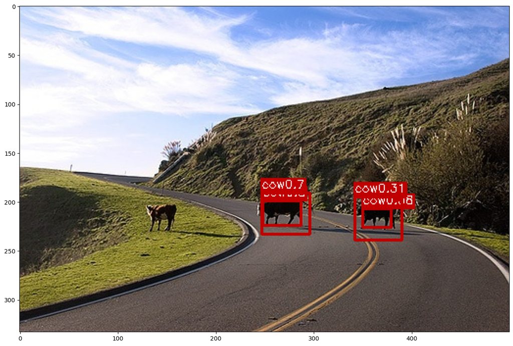

```python
net.eval()

# select random image from test set
image_name = random.choice(test_dataset.fnames)
image = cv2.imread(os.path.join(file_root_test, image_name))
image = cv2.cvtColor(image, cv2.COLOR_BGR2RGB)

print('predicting...')
result = predict_image(net, image_name, root_img_directory=file_root_test)
for left_up, right_bottom, class_name, _, prob in result:
    color = COLORS[VOC_CLASSES.index(class_name)]
    cv2.rectangle(image, left_up, right_bottom, color, 2)
    label = class_name + str(round(prob, 2))
    text_size, baseline = cv2.getTextSize(label, cv2.FONT_HERSHEY_SIMPLEX, 0.4, 1)
    p1 = (left_up[0], left_up[1] - text_size[1])
    cv2.rectangle(image, (p1[0] - 2 // 2, p1[1] - 2 - baseline), (p1[0] + text_size[0], p1[1] + text_size[1]),
                  color, -1)
    cv2.putText(image, label, (p1[0], p1[1] + baseline), cv2.FONT_HERSHEY_SIMPLEX, 0.4, (255, 255, 255), 1, 8)
# print(image.shape)
# im = Image.new(image,size =(375,500))
plt.close('all')  # closes all previous figures
plt.figure(figsize = (15,15))
plt.imshow(image)
plt.show()
```

## Evaluate on Test

To evaluate detection results we use mAP (mean of average precision over each class)

```python
test_aps = evaluate(net, test_dataset_file=annotation_file_test, img_root=file_root_test)
```

```
---Evaluate model on test samples---
```

```
---class aeroplane ap 0.5199347133762378---
---class bicycle ap 0.6450768543333061---
---class bird ap 0.4755365579429922---
---class boat ap 0.30737793462051---
---class bottle ap 0.2251165204198575---
---class bus ap 0.6444623868161096---
---class car ap 0.6771611815121986---
---class cat ap 0.7506164934794777---
---class chair ap 0.3184645416355998---
---class cow ap 0.571003279436451---
---class diningtable ap 0.42045781590074527---
---class dog ap 0.7120105384546528---
---class horse ap 0.7259033330174778---
---class motorbike ap 0.5900654800044449---
---class person ap 0.5560240021108713---
---class pottedplant ap 0.20281269780599842---
---class sheep ap 0.5139754075810762---
---class sofa ap 0.4963874931959104---
---class train ap 0.686051554091478---
---class tvmonitor ap 0.520484378909302---
---map 0.5279461582322349---
```

### Cell added to get intermediate mAP values for students

```python
network_paths = ['./checkpoints/detector_epoch_%d.pth' % epoch for epoch in [5, 10, 20, 30, 40]]+['./checkpoints/detector.pth']
for load_network_path in network_paths:
    print('Loading saved network from {}'.format(load_network_path))
    net_loaded =  resnet50().to(device)
    net_loaded.load_state_dict(torch.load(load_network_path))
    evaluate(net_loaded, test_dataset_file=annotation_file_test, img_root=file_root_test)
```

```
Loading saved network from ./checkpoints/detector_epoch_5.pth
---Evaluate model on test samples---
```

```
---class aeroplane ap 0.5043015282278073---
---class bicycle ap 0.6773606137621415---
---class bird ap 0.44120655042767154---
---class boat ap 0.3099732563984594---
---class bottle ap 0.14375537777761727---
---class bus ap 0.6226174894737079---
---class car ap 0.6408518217644554---
---class cat ap 0.7202477122819776---
---class chair ap 0.2830660821498139---
---class cow ap 0.5343924785756844---
---class diningtable ap 0.39049601310690446---
---class dog ap 0.7003474780529089---
---class horse ap 0.709946997774902---
---class motorbike ap 0.5869946522882454---
---class person ap 0.500431298258442---
---class pottedplant ap 0.17273352365610106---
---class sheep ap 0.451075143224862---
---class sofa ap 0.4511487227192126---
---class train ap 0.636534752306345---
---class tvmonitor ap 0.47180636270716836---
---map 0.4974643927467214---
Loading saved network from ./checkpoints/detector_epoch_10.pth
---Evaluate model on test samples---
```

```
---class aeroplane ap 0.5110567491542779---
---class bicycle ap 0.674480392409495---
---class bird ap 0.4780949143035722---
---class boat ap 0.32924003045234157---
---class bottle ap 0.1794282706619576---
---class bus ap 0.6534453182960254---
---class car ap 0.6756108689264962---
---class cat ap 0.7452438391597491---
---class chair ap 0.31853263580898583---
---class cow ap 0.5412112448838335---
---class diningtable ap 0.4021632294061467---
---class dog ap 0.6661154121963877---
---class horse ap 0.6877876659752677---
---class motorbike ap 0.6025386560725838---
---class person ap 0.5372200630967134---
---class pottedplant ap 0.20253881333901438---
---class sheep ap 0.5220922571866156---
---class sofa ap 0.45537918241163866---
---class train ap 0.6397049940836173---
---class tvmonitor ap 0.510919574874078---
---map 0.5166402056349398---
Loading saved network from ./checkpoints/detector_epoch_20.pth
---Evaluate model on test samples---
```

```
---class aeroplane ap 0.5006551915521552---
---class bicycle ap 0.6521257371183233---
---class bird ap 0.5038827315301657---
---class boat ap 0.31808675488603955---
---class bottle ap 0.19228929347757973---
---class bus ap 0.6397279278990682---
---class car ap 0.6703458933671793---
---class cat ap 0.7204356908763405---
---class chair ap 0.31472819355040776---
---class cow ap 0.5327150778903096---
---class diningtable ap 0.4099861993724629---
---class dog ap 0.6795501071438432---
---class horse ap 0.6901173009282385---
---class motorbike ap 0.5725876614730714---
---class person ap 0.5278891205282898---
---class pottedplant ap 0.20185695873046092---
---class sheep ap 0.5622749196434329---
---class sofa ap 0.466511382098481---
---class train ap 0.6638215654472981---
---class tvmonitor ap 0.5078679577865801---
---map 0.5163727832649865---
Loading saved network from ./checkpoints/detector_epoch_30.pth
---Evaluate model on test samples---
```

```
---class aeroplane ap 0.5126408624461706---
---class bicycle ap 0.6499911891811943---
---class bird ap 0.47430859538089265---
---class boat ap 0.30421514218030643---
---class bottle ap 0.21771085357592287---
---class bus ap 0.6351766447915375---
---class car ap 0.6521439609898358---
---class cat ap 0.7354743703531407---
---class chair ap 0.2972013341432842---
---class cow ap 0.5426697589065007---
---class diningtable ap 0.391612006607638---
---class dog ap 0.7103116364205384---
---class horse ap 0.7093316806054522---
---class motorbike ap 0.5964583079009742---
---class person ap 0.5393025843265367---
---class pottedplant ap 0.20267669908772426---
---class sheep ap 0.5168750789040628---
---class sofa ap 0.4833555047635203---
---class train ap 0.6726179563715806---
---class tvmonitor ap 0.5242733964409693---
---map 0.5184173781688891---
Loading saved network from ./checkpoints/detector_epoch_40.pth
---Evaluate model on test samples---
```

```
---class aeroplane ap 0.5403329088723057---
---class bicycle ap 0.6556543122399183---
---class bird ap 0.48245977564699144---
---class boat ap 0.320627798817953---
---class bottle ap 0.22093955822030714---
---class bus ap 0.6629476605249436---
---class car ap 0.6731571927762183---
---class cat ap 0.7523523345257749---
---class chair ap 0.30703935003731087---
---class cow ap 0.5721623901763406---
---class diningtable ap 0.41948266224621017---
---class dog ap 0.7113147473374744---
---class horse ap 0.7049122825553402---
---class motorbike ap 0.594526539702253---
---class person ap 0.549978898577127---
---class pottedplant ap 0.19079762070785428---
---class sheep ap 0.5179085645579579---
---class sofa ap 0.487863932501518---
---class train ap 0.6926581650418158---
---class tvmonitor ap 0.5210537105530005---
---map 0.5289085202809308---
Loading saved network from ./checkpoints/detector.pth
---Evaluate model on test samples---
```

```
---class aeroplane ap 0.5199347133762378---
---class bicycle ap 0.6450768543333061---
---class bird ap 0.4755365579429922---
---class boat ap 0.30737793462051---
---class bottle ap 0.2251165204198575---
---class bus ap 0.6444623868161096---
---class car ap 0.6771611815121986---
---class cat ap 0.7506164934794777---
---class chair ap 0.3184645416355998---
---class cow ap 0.571003279436451---
---class diningtable ap 0.42045781590074527---
---class dog ap 0.7120105384546528---
---class horse ap 0.7259033330174778---
---class motorbike ap 0.5900654800044449---
---class person ap 0.5560240021108713---
---class pottedplant ap 0.20281269780599842---
---class sheep ap 0.5139754075810762---
---class sofa ap 0.4963874931959104---
---class train ap 0.686051554091478---
---class tvmonitor ap 0.520484378909302---
---map 0.5279461582322349---
```

```python
output_submission_csv('my_solution.csv', test_aps)
```